# rco-optimization-example-by-Rahul Saxena

Rahul Saxena

22/01/2020

## Problem Statement:

Write a chunk of code that would result automatically optimized by applying the **rco::optimize_files** function, and compare its execution time *(with microbenchmark::microbenchmark)* against the non-optimized code. This should be submited as a vignette named *“rco-optimization-example-by-STUDENT.Rmd”.*

Below is the code, I originally had and the optimized code that I recieved as a result of using the *rco::optimize_files* function.

### Original Code

```r
test <- function()
{
  years_old <- 29
  days_old <- 365 * years_old # leap years don't exist",
  hours_old <- 24 * days_old
  seconds_old <- 60 * 60 * hours_old
  if (seconds_old > 10e6) {
    print("Whoa! More than a million seconds old, what a wise man!")
  } else {
    print("Meh!")
  }
}
```

### Optimized Code {6 number of optimizations}

```r
optimized_test <- function()
{
  years_old <- 29
  days_old <- 10585 # leap years don't exist",
  hours_old <- 254040
  seconds_old <- 914544000
  print("Whoa! More than a million seconds old, what a wise man!")
}
```

## Plots

### Plots for non-optimized code

Using the *plot()* function.

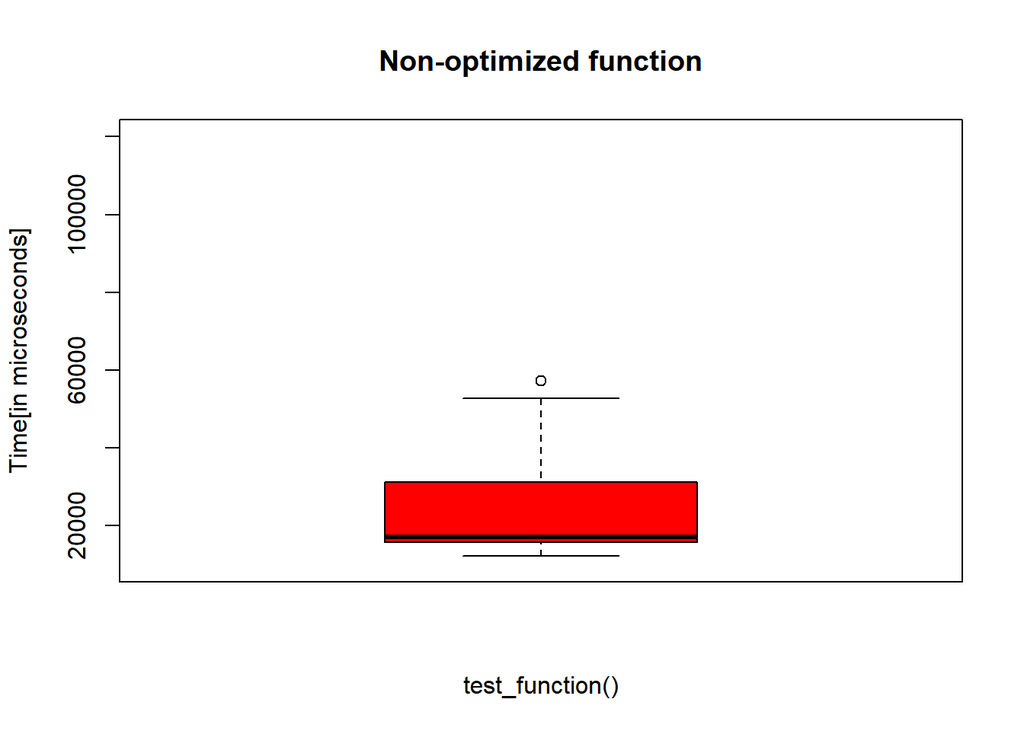

```r
test <- function()
{
  years_old <- 29
  days_old <- 365 * years_old # leap years don't exist",
  hours_old <- 24 * days_old
  seconds_old <- 60 * 60 * hours_old
  if (seconds_old > 10e6) {
    print("Whoa! More than a million seconds old, what a wise man!")
  } else {
    print("Meh!")
  }
}

plot_obj <- microbenchmark::microbenchmark(test(), times = 1000L)
```

Using the *autoplot()* function.

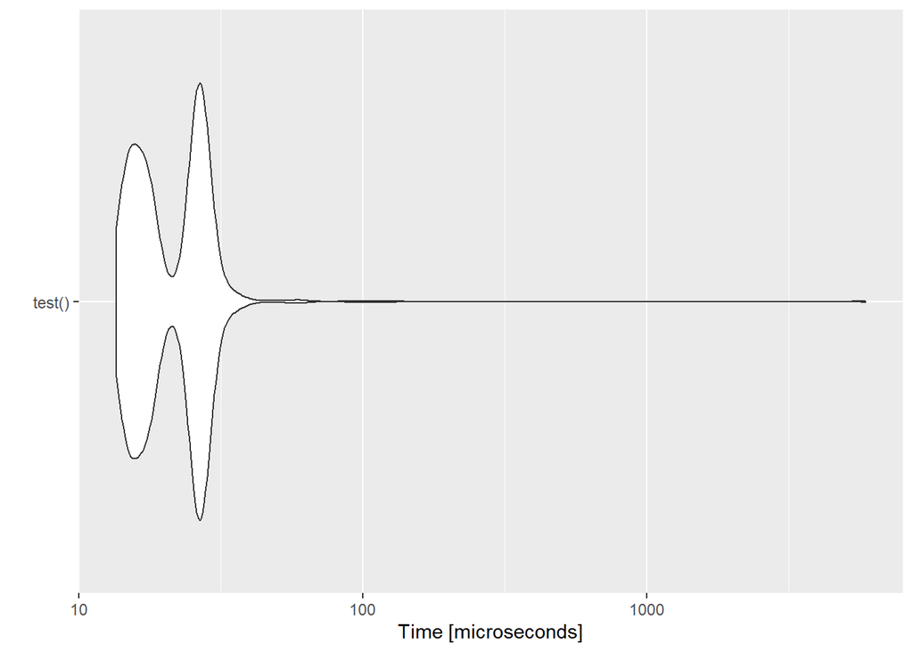

```r
test <- function()
{
  years_old <- 29
  days_old <- 365 * years_old # leap years don't exist",
  hours_old <- 24 * days_old
  seconds_old <- 60 * 60 * hours_old
  if (seconds_old > 10e6) {
    print("Whoa! More than a million seconds old, what a wise man!")
  } else {
    print("Meh!")
  }
}

plot_obj <- microbenchmark::microbenchmark(test(), times = 1000L)
```